# SPARK SQL (CLOUDS Fall 2018)

### Question 4.2

You will realize that saying *"at 4 A.M. there is a very low chance of a flight being delayed"* is not giving you a full picture of the situation. Indeed, it might be true that there is very little probability for an early flight to be delayed, but if it does, the delay might be huge, like 6 hours!

Then, the question is: **which hours of the day are characterized by the largest mean delay?** (you can consider the median too) Plot a Bar chart and explain it.

```
Text(0,0.5,'Delay')
```

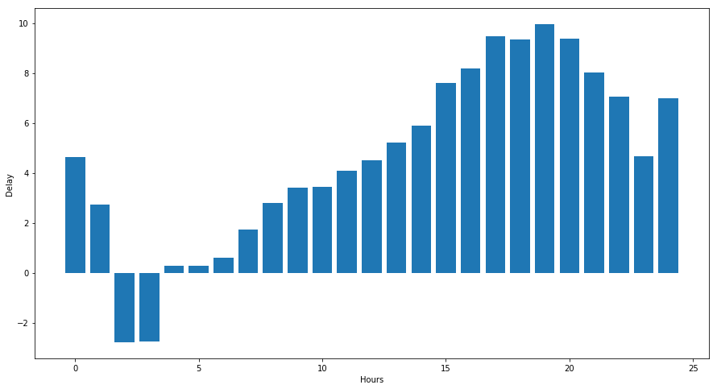

```python
avg_delays_DF = DFwithdelayAndHour.groupBy('hour').avg('arrival_delay').orderBy('hour').collect()

plt.figure(figsize=(15,8))
plt.bar([x for x in range(len(avg_delays_DF))], [x[1] for x in avg_delays_DF])
plt.xlabel("Hours")
plt.ylabel("Delay")
```

```python
print("We can see flights at 2am and 3 am have negative values which symbolizes that in average,they land earlier than the scheduled arrival time. And the most average delay is still at the evening time")
```

```
We can see flights at 2am and 3 am have negative values which symbolizes that in average,they land earlier than the scheduled arrival time. And the most average delay is still at the evening time
```

So, an attentive student should notice here that we have somehow a problem with the definition of delay! Next, we will improve how to represent and visualize data to overcome this problem.

**NOTE**: the following piece of code assumes you correctly answered the previous questions. The naming convention of the DataFrames we use next should be clear enough for you to produce them by answering the questions above.

```python
pdf_delay_ratio_per_hour = pd.DataFrame(data=avg_delays_DF)
```

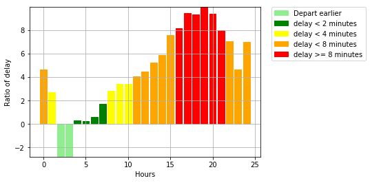

```python
#pdf2 = pd.DataFrame(data=mean_delay_per_hour.collect())
plt.xlabel("Hours")
plt.ylabel("Ratio of delay")
#plt.title('Figure 6: The radio of delay over hours in day')
plt.grid(True,which="both",ls="-")
bars = plt.bar(pdf_delay_ratio_per_hour[0], pdf_delay_ratio_per_hour[1], align='center', edgecolor = "black")
for i in range(0, len(bars)):
    color = 'red'
    if pdf_mean_delay_per_hour[1][i] < 0:
        color = 'lightgreen'
    elif pdf_mean_delay_per_hour[1][i] < 2:
        color = 'green'
    elif pdf_mean_delay_per_hour[1][i] < 4:
        color = 'yellow'
    elif pdf_mean_delay_per_hour[1][i] < 8:
        color = 'orange'

    bars[i].set_color(color)

patch1 = mpatches.Patch(color='lightgreen', label='Depart earlier')
patch2 = mpatches.Patch(color='green', label='delay < 2 minutes')
patch3 = mpatches.Patch(color='yellow', label='delay < 4 minutes')
patch4 = mpatches.Patch(color='orange', label='delay < 8 minutes')
patch5 = mpatches.Patch(color='red', label='delay >= 8 minutes')

plt.legend(handles=[patch1, patch2, patch3, patch4, patch5], bbox_to_anchor=(1.05, 1), loc=2, borderaxespad=0.)
plt.margins(0.05, 0)
plt.show()
```

This example shows us that the way representing results are also important.